# Artificial Intelligence Course - Fall 1402

## Computer Assignment #2 - Reinforcement Learning

## Amirmahdi Farzane - 810100194

```python
!apt-get install python-opengl -y

!apt install xvfb -y

!pip install pyvirtualdisplay

!pip install piglet
```

[output not shown]

```python
from pyvirtualdisplay import Display
Display().start()
```

```
<pyvirtualdisplay.display.Display at 0x7d38ba1b2830>
```

```python
import time
```

```python
import gym
from IPython import display
import matplotlib.pyplot as plt
%matplotlib inline
```

- Part 1: Value Iteration & Policy Iteration Algorithms
  - َQuestion 1:
  - َQuestion 2:
  - َQuestion 3:
  - َQuestion 4:
  - َQuestion 5:
    - Value Iteration
    - Policy Iteration
  - َQuestion 6:
    - Value Iteration
    - Policy Iteration
- Part 2: Q-Learning Algorithm
  - َQuestion 8:
  - َQuestion 9:
  - َQuestion 10:

```python
# import
import numpy as np
import gym
import time
```

## Part 1: Value Iteration & Policy Iteration Algorithms

```python
env = gym.make('FrozenLake-v1' , desc=None , map_name="4x4"  , is_slippery=False)
```

```python
# Total no. of states
states_number = env.observation_space.n
```

```python
# Total no. of actions
actions_number = env.action_space.n
```

```python
REPEAD_NUM = 100
```

```python
value_iter_episods = []
value_iter_time = []
policy_iter_episods = []
policy_iter_time = []
```

### Question 1:

This algorithm , calculate value of all actions for each state in every step and choose the best value for each state between all possible actions. We dont use policy and our action be choosed based on their values.

### Question 2:

```python
class ValueIteration():
    def __init__(self, env, discount_factor, theta=1e-8):
        self.env = env
        self.discount_factor = discount_factor
        self.theta = theta
        self.reset()
        self.state_values = np.ones((self.env.observation_space.n)) / self.env.action_space.n
        self.q_values = np.ones((self.env.observation_space.n, self.env.action_space.n)) / self.env.action_space.n
        self.state_values[self.env.observation_space.n - 1] = 0
        self.q_values[self.env.observation_space.n - 1] = np.zeros((self.env.action_space.n))

    def value_estimation(self):
        self.delta = np.inf
        i=0
        while(self.delta > self.theta):
            begin_time = time.time()
            i = i+1
            self.delta = 0

            for state in range(self.env.observation_space.n):

                v = self.state_values[state]

                for action in range(self.env.action_space.n):
                    action_value = 0
                    for probability, next_state, reward, done in self.env.P[state][action]:
                        ### START CODE HERE ###
                         next_state_value = self.state_values[next_state]

                         action_value += probability*(reward + self.discount_factor* next_state_value)
                        ### END CODE HERE ###
                    self.q_values[state, action] = action_value

                self.state_values[state] = np.max(self.q_values[state,:])

                self.delta = np.max([self.delta, abs(v - self.state_values[state])])

                if (self.delta < self.theta):
                    value_iter_episods.append(i)
                    value_iter_time.append(time.time() - begin_time)
                    break

    def take_action(self, action):
        next_state, reward, done, _ = self.env.step(action)
        return next_state, reward, done

    def get_optimal_policy(self, state):
        return np.argmax(self.q_values[state,:])

    def get_state_values(self):
        return self.state_values

    def get_q_values(self):
        return self.q_values

    def reset(self):
        initial_state = self.env.reset()
        return initial_state
```

### Question 3:

In this algorithm, first choose a random policy and evaluate value of each state.And after converging for a policy we choose a better policy and improve that based on results of previous step by evaluating value of all actions for each states.And we do two steps again until converged policy be stabel.

### Question 4:

```python
class PolicyIteration():
    def __init__(self, env, discount_factor, theta=1e-8):
        self.env = env
        self.discount_factor = discount_factor
        self.theta = theta
        self.reset()
        self.state_values = np.ones((self.env.observation_space.n)) / self.env.action_space.n
        self.q_values = np.ones((self.env.observation_space.n, self.env.action_space.n)) / self.env.action_space.n
        self.state_values[self.env.observation_space.n - 1] = 0
        self.q_values[self.env.observation_space.n - 1] = np.zeros((self.env.action_space.n))
        self.policy = np.random.randint(self.env.action_space.n, size=self.env.observation_space.n) # initial policy
        self.policy_stable = False
        self.counter = 0

    def policy_evaluation(self):
        self.delta = np.inf
        self.counter+=1
        while(self.delta >= self.theta):

            self.delta = 0

            for state in range(self.env.observation_space.n):

                v = self.state_values[state]

                new_state_value = 0
                for probability, next_state, reward, done in self.env.P[state][self.policy[state]]:
                    ### START CODE HERE ###
                    new_state_value += (probability*(reward + self.discount_factor* self.state_values[next_state]))
                    ### END CODE HERE ###
                self.state_values[state] = new_state_value

                self.delta = np.max([self.delta, abs(v - self.state_values[state])])

    def policy_improvement(self):
        self.policy_stable = True

        for state in range(self.env.observation_space.n):
            old_policy = self.policy[state]

            for action in range(self.env.action_space.n):

                action_value = 0
                for probability, next_state, reward, done in self.env.P[state][action]:
                    ### START CODE HERE ###
                    action_value += (probability*(reward + self.discount_factor* self.state_values[next_state]))
                    ### END CODE HERE ###
                self.q_values[state, action] = action_value

            self.policy[state] = np.argmax(self.q_values[state,:])

            if old_policy != self.policy[state]:
                self.policy_stable = False

    def policy_estimation(self):
        self.policy_stable = False
        begin_time = time.time()
        while not self.policy_stable:
            self.policy_evaluation()
            self.policy_improvement()
        policy_iter_episods.append(self.counter)
        policy_iter_time.append(time.time() - begin_time)
        self.counter=0



    def take_action(self, action):
        next_state, reward, done, _ = self.env.step(action)
        return next_state, reward, done

    def get_optimal_policy(self, state):
        return self.policy[state]

    def get_state_values(self):
        return self.state_values

    def get_q_values(self):
        return self.q_values

    def reset(self):
        initial_state = self.env.reset()
        return initial_state
```

### Question 5:

#### Value Iteration:

```python
import matplotlib.pyplot as plt
import matplotlib.table as Table

def make_plt(pre_table):
  pre_table = pre_table.tolist()
  my_table = [[]for i in range(4)]
  for i in range(16):
    my_table[i//4].append('%.2f' %pre_table[i])
  fig, ax = plt.subplots()

  table = ax.table(cellText=my_table, loc='center', cellLoc='center', colWidths=[0.2] * 4)
  table.auto_set_font_size(False)
  table.set_fontsize(18)
  table.scale(6, 6)

  ax.axis('off')

  plt.show()
```

```python
for i in range(REPEAD_NUM):
    val_iter = ValueIteration(env , 0.9 )
    val_iter.value_estimation()
```

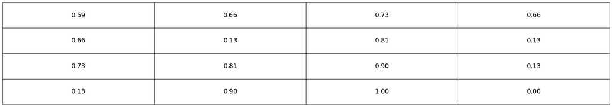

```python
make_plt(val_iter.get_state_values())
```

```python
def render_ (val_iter):
  img = plt.imshow(val_iter.env.render('rgb_array')) # only call this once
  state = 0
  done=0
  for _ in range(10):
      img.set_data(val_iter.env.render('rgb_array')) # just update the data
      display.display(plt.gcf())
      display.clear_output(wait=True)
      action = val_iter.get_optimal_policy(state)
      if done :
        break
      state ,_ ,done = val_iter.take_action(action)

      time.sleep(2)
```

[figure not shown]

```python
render_(val_iter)
```

```python
def make_string_plt(pre_table):
  my_table = [[]for i in range(4)]
  for i in range(16):
    my_table[i//4].append(pre_table[i])
  fig, ax = plt.subplots()

  table = ax.table(cellText=my_table, loc='center', cellLoc='center', colWidths=[0.1] * 4)
  table.auto_set_font_size(False)
  table.set_fontsize(35)
  table.scale(6, 6)

  ax.axis('off')

  plt.show()
```

```python
opt_policy_value_table = []
for i in range(15):
  if(val_iter.get_optimal_policy(i) == 0):
    opt_policy_value_table.append("⬅")
  elif(val_iter.get_optimal_policy(i) == 1):
    opt_policy_value_table.append("⬇")
  elif(val_iter.get_optimal_policy(i) == 2):
    opt_policy_value_table.append("➡")
  elif(val_iter.get_optimal_policy(i) == 3):
    opt_policy_value_table.append("⬆")
opt_policy_value_table.append("✰")
```

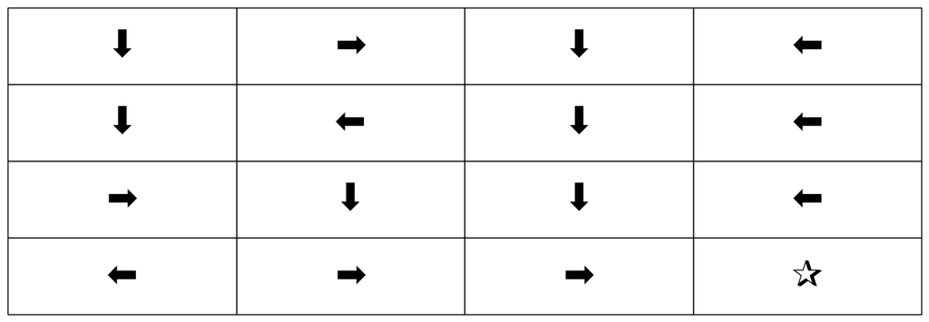

```python
make_string_plt(opt_policy_value_table)
```

```python
def make_value_plt(pre_table):
  pre_table = pre_table.tolist()
  my_table = [[]for i in range(17)]
  my_table[0] = [ "", "left" , "down" , "right" , "up"]
  sn = 1

  for state in pre_table:
    s_string="state "
    s_string+=str(sn)
    my_table[sn].append(s_string)
    for i in range(4):
      my_table[sn].append('%.2f' %state[i])
    sn+=1
  fig, ax = plt.subplots()

  table = ax.table(cellText=my_table, loc='center', cellLoc='center', colWidths=[0.2] * 5)
  table.auto_set_font_size(False)
  table.set_fontsize(18)
  table.scale(6, 6)

  ax.axis('off')

  plt.show()
```

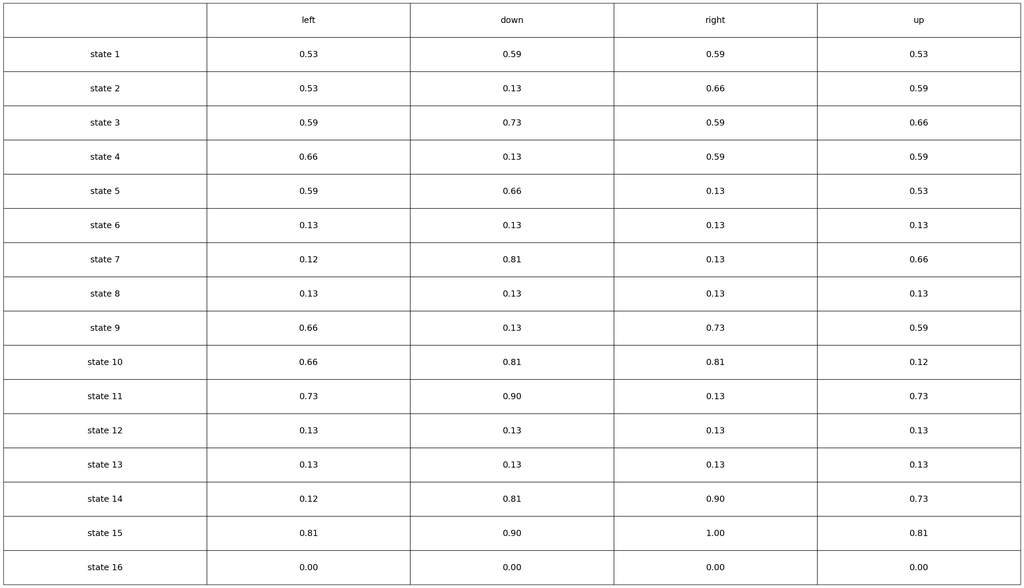

```python
make_value_plt(val_iter.get_q_values())
```

#### Policy Iteration:

```python
env_policy = gym.make('FrozenLake-v1' , desc=None , map_name="4x4"  , is_slippery=False)
policy_iter = PolicyIteration(env_policy , 0.9 )
```

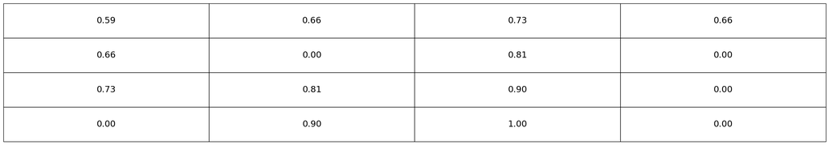

```python
for i in range(REPEAD_NUM):
    policy_iter = PolicyIteration(env_policy , 0.9 )
    policy_iter.policy_estimation()
make_plt(policy_iter.get_state_values())
```

[figure not shown]

```python
render_(policy_iter)
```

```python
opt_policy_policy_table = []
for i in range(15):
  if(policy_iter.get_optimal_policy(i) == 0):
    opt_policy_policy_table.append("⬅")
  elif(policy_iter.get_optimal_policy(i) == 1):
    opt_policy_policy_table.append("⬇")
  elif(policy_iter.get_optimal_policy(i) == 2):
    opt_policy_policy_table.append("➡")
  elif(policy_iter.get_optimal_policy(i) == 3):
    opt_policy_policy_table.append("⬆")
opt_policy_policy_table.append("✰")
```

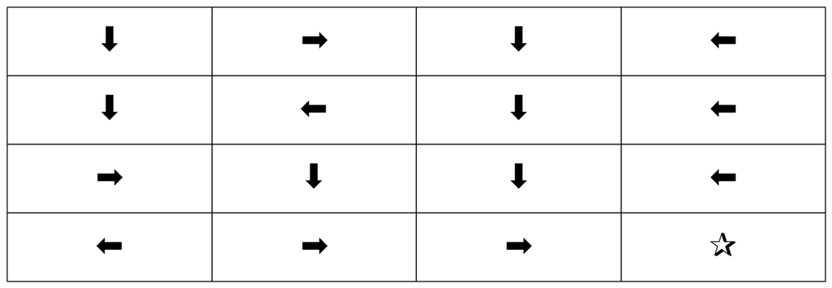

```python
make_string_plt(opt_policy_policy_table)
```

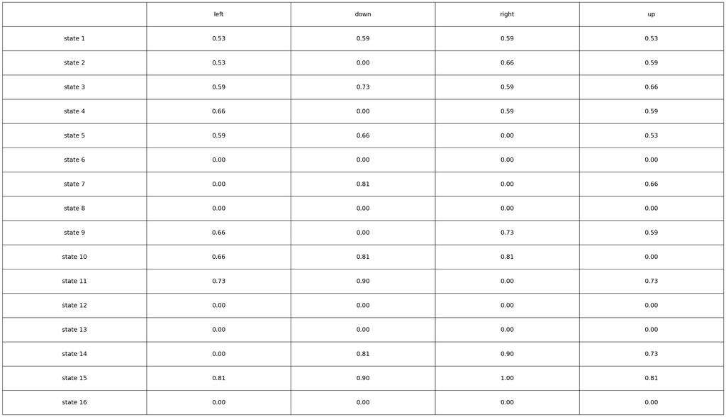

```python
make_value_plt(policy_iter.get_q_values())
```

### Question 6:

As wee see states values and optimal policy for both is simmilar because after some episodes both of them find same q values . Just policy iteration after converging changes policy and value iteration find simmilar by checking in each episode.

State value for water holes in value iteration is 0.13 but in policy iteration is 0 .We update state in value iteration of trap because we allow that to do best action in each step and at the start of iterating choose this home.But policy just follow its rule and update that and never update traps.Beacause in value iteration we converge soonner so we don't update it to get 0 bu in policy we explorein environment more than value iteration so we get 0.

```python
print(len(policy_iter_episods))
```

```
100
```

```python
episodes_indes = [i for i in range(1,101)]
```

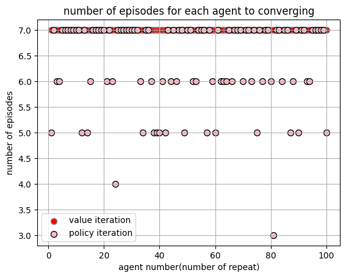

```python
plt.scatter(episodes_indes, value_iter_episods, c ="red",
            linewidths = 1,
            marker ="o",
            edgecolor ="gray",
            s = 50)
plt.scatter(episodes_indes, policy_iter_episods, c ="pink",
            linewidths = 1,
            marker ="o",
            edgecolor ="black",
            s = 50)

plt.legend(["value iteration" , "policy iteration"])
plt.xlabel("agent number(number of repeat)")
plt.ylabel("number of episodes")
plt.title("number of episodes for each agent to converging")

# plt.plot(episode_x, reward_y)
plt.grid()
plt.show()
```

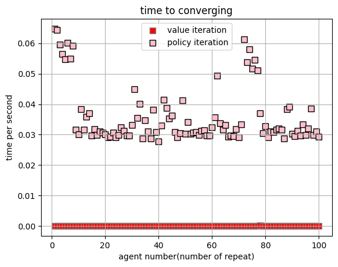

```python
plt.scatter(episodes_indes, value_iter_time, c ="red",
            linewidths = 1,
            marker ="s",
            edgecolor ="gray",
            s = 50)
plt.scatter(episodes_indes, policy_iter_time, c ="pink",
            linewidths = 1,
            marker ="s",
            edgecolor ="black",
            s = 50)

plt.legend(["value iteration" , "policy iteration"])
plt.xlabel("agent number(number of repeat)")
plt.ylabel("time per second")
plt.title("time to converging")

plt.grid()
plt.show()
```

As we see above , needed episods for policy iteration for some agents is less but for all value iteration agensts is same. But converging time in policy-iteration is more .I think in this example because of small space of problem , value iteration in few steps could find best policy but in larger spaces repeat this method take a lot of time where policy can find answer faster with few episodes .

## Part 2: Q-Learning Algorithm

# Q7

Q-Learning is a Reinforcement learning algorithm that will find the next best action, given a current state. It chooses this action at random and aims to maximize the reward.We decrease randomnes after each episode.

Q-learning is a model-free, off-policy reinforcement learning that will find the best course of action, given the current state of the agent. Depending on where the agent is in the environment, it will decide the next action to be taken.

The objective of the model is to find the best course of action given its current state. To do this, it may come up with rules of its own or it may operate outside the policy given to it to follow. This means that there is no actual need for a policy, hence we call it off-policy.

```python
# hyperparameters
REPS = 20
EPISODES = 2000
EPSILON = 0.1
LEARNING_RATE = 0.1
DISCOUNT = 0.9
STUDENT_NUM = 194
ACTIONS=  [0,1,2,3,4,5]
```

```python
# environment
taxi_env = gym.make('Taxi-v3')
taxi_env.seed(seed = STUDENT_NUM)
Initial_State = taxi_env.reset()
Initial_State
```

```
429
```

```python
taxi_row, taxi_col, pass_idx, dest_idx = taxi_env.decode(Initial_State)
```

### Question 8:

```python
from numpy.random.mtrand import rand
import random
class QLearningAgent():
    def __init__(self, env, epsilon, learning_rate, discount_factor, seed):
      self.env = env
      self.epsilon = epsilon
      self.learning_rate = learning_rate
      self.olr = learning_rate
      self.discount_factor = discount_factor
      self.q_table = np.zeros((env.observation_space.n, env.action_space.n))
      self.seed = seed
      self.explor_dacay = 0.99
      self.alpha_dec = 0.99

    def choose_action(self, state):
      ### START CODE HERE ###
      # With probability epsilon, choose a random action
      action=0
      if(rand() < self.epsilon):
        action = random.randint(0,5)
      # Otherwise, choose the action with the highest Q-value
      else:
        action = self.get_optimal_policy(state)
      ### END CODE HERE ###
      return action

    def update_q_table(self, state, action, nextState, reward):
      ### START CODE HERE ###
      # Calculate the new Q-value using the Q-learning formula

      self.q_table[state][action] = (1-LEARNING_RATE)*self.q_table[state][action] + LEARNING_RATE * (reward  + DISCOUNT*(np.max(self.q_table[nextState])))
      ### END CODE HERE ###

    def decay_epsilon(self, episode):
      ### START CODE HERE ###
      self.epsilon = 1 / (1+  10*(episode))
      # self.epsilon = max(0.1 ,((EPISODES-episode)/EPISODES)*1 )
      ### END CODE HERE ###

    def decrease_learning_rate(self, episode):
      ### START CODE HERE ###
      self.learning_rate =1 / (1+  10*(episode))
      # self.learning_rate = ((EPISODES-episode)/EPISODES)*0.1
      ### END CODE HERE ###

    def take_action(self, action):
      next_state, reward, done, _ = self.env.step(action)
      return next_state, reward, done

    def get_optimal_policy(self, state):
      return np.argmax(self.q_table[state])

    def get_q_values(self):
      return self.q_table

    def reset(self):
      # self.learning_rate = self.olr
      return self.env.reset(seed=self.seed)
```

```python
import matplotlib.pyplot as plt
import numpy as np
from scipy.interpolate import interp1d
```

```python
# for rep in range(REPS):
import time
def train_taxi(taxi_env , change_alpha):
  agents_list = []
  total_rewards = [[0 for i in range(REPS)] for j in range(EPISODES)]
  total_times = [[0 for i in range(REPS)] for j in range(EPISODES)]
  for agent_num in range(REPS):
    agent = QLearningAgent(taxi_env, EPSILON, LEARNING_RATE, DISCOUNT, STUDENT_NUM)
    for episode in range(EPISODES):
        state = taxi_env.reset(seed=STUDENT_NUM)

        done = 0

        rew_per_epi = 0
        episode_start_time = time.time()
        while not done :

            bestAction = agent.choose_action(state)

            next_state,rew,done = agent.take_action(bestAction)
            rew_per_epi+=rew
            # render_taxi(agent.env)
            agent.update_q_table(state, bestAction, next_state, rew)
            state = next_state
            if(done):
              total_rewards[episode][agent_num] = rew_per_epi
              total_times[episode][agent_num] = time.time() - episode_start_time
              break

        agent.decay_epsilon(episode)

        if change_alpha:
          agent.decrease_learning_rate(episode)
    agents_list.append(agent)

  find_best_agent = np.array([0 for i in range(REPS)])
  for i in range(EPISODES):
    for j in range(REPS):
      find_best_agent[j]+=total_rewards[i][j]
  best_agent_index = np.argmax(find_best_agent)

  return agents_list[best_agent_index] , total_rewards ,total_times
```

```python
agent_fixed_alpha , total_rewards_f , time_f = train_taxi(taxi_env , change_alpha = 0)
agent_nfixed_alpha , total_rewards_n , time_n = train_taxi(taxi_env , change_alpha = 1)
```

```python
episode_x_fixed = []
reward_y_fixed = []
episode_x_nfixed = []
reward_y_nfixed = []

time_y_fixed = []
time_y_nfixed = []
```

Final reward of each agent is 6.

```python
total_rewards_f[-1]
```

```
[6, 6, 6, 6, 6, 6, 6, 6, 6, 6, 6, 6, 6, 6, 6, 6, 6, 6, 6, 6]
```

```python
for i in range(EPISODES):
  episode_x_fixed.append(i+1)
  reward_y_fixed.append(sum(total_rewards_f[i])/REPS)
  episode_x_nfixed.append(i+1)
  reward_y_nfixed.append(sum(total_rewards_n[i])/REPS)

  time_y_fixed.append(sum(time_f[i])/REPS)
  time_y_nfixed.append(sum(time_n[i])/REPS)
```

# Question 9 :

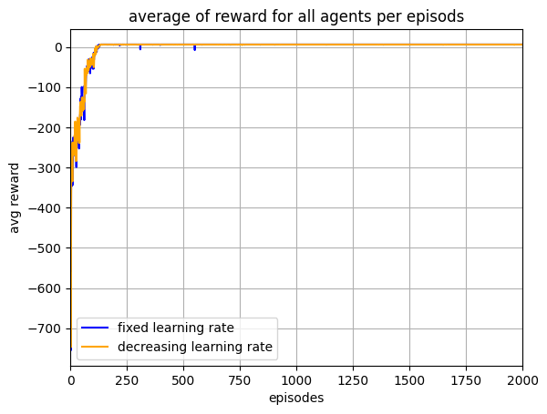

```python
plt.plot(episode_x_fixed, reward_y_fixed,"blue")
plt.plot(episode_x_nfixed, reward_y_nfixed,"orange")
plt.xlim(0,2000)
plt.legend(["fixed learning rate" , "decreasing learning rate"])
plt.xlabel("episodes")
plt.ylabel("avg reward")
plt.title("average of reward for all agents per episods")

# plt.plot(episode_x, reward_y)
plt.grid()
plt.show()
```

Converged value for both method is simmilar and is 6.

We see a glich because we have a little chance of changing epsilon for exploration and changing choosing action method and choosing randomly is resaon of this glich.

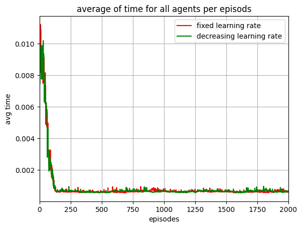

```python
plt.plot(episode_x_fixed, time_y_fixed,"red")
plt.plot(episode_x_nfixed, time_y_nfixed,"green")
plt.xlim(0,2000)
plt.legend(["fixed learning rate" , "decreasing learning rate"])
plt.xlabel("episodes")
plt.ylabel("avg time")
plt.title("average of time for all agents per episods")

# plt.plot(episode_x, reward_y)
plt.grid()
plt.show()
```

### Question 10:

```python
def render_taxi (taxi,state):
  sum =0
  done=0
  for i in range(100):
    img = plt.imshow(taxi.env.render('rgb_array')) # only call this once
    # state = 0
    img.set_data(taxi.env.render('rgb_array')) # just update the data
    # img.set_data(1)
    string = "score : "
    string+=str(sum)
    plt.text(50, -10, string, fontsize = 22)
    display.display(plt.gcf())
    display.clear_output(wait=True)
    plt.close()
    if(done):
      break
    action = taxi.get_optimal_policy(state)
    state ,rew ,done = taxi.take_action(action)

    sum+=rew
    time.sleep(1)
    if done:
      continue
```

[figure not shown]

```python
TEST_NUM=1
for i in range(TEST_NUM):
  state = taxi_env.reset(seed  = STUDENT_NUM)
  render_taxi(agent_fixed_alpha , state)
```